## Regression Models Course Project

#### Title: mtcars Regression Analysis by Brian Hudnall

#### Executive Summary:

##### Results:

Manual Transmissions lead to higher MPGs. The result is based on a multivariate regression analysis model that calculates the relationship of MPGs to manual and automatic transmissions; model accounts for car weight and 1/4 mile time. Results show that a Manual transmission car leads to a 2.94 higher unit increase in MPGs compared to an automatic at a statistically significant P-value of less than .05. Model also accounts for 85% of the variance.

#### Exploratory Data Analysis:

First, load the necessary packages used in analysis.

```r
require(UsingR)
require(dplyr)
require(ggplot2)
require(GGally)
require(leaps)
```

Next, explore the dataset and understand the values included:

```r
glimpse(mtcars)

## Pull up details of the mtcars dataset
help(mtcars)
```

Below is the output from the help command above: A data frame with 32 observations on 11 variables.

1. [, 1] mpg Miles/(US) gallon 2. [, 2] cyl Number of cylinders 3. [, 3] disp Displacement (cu.in.) 4. [, 4] hp Gross horsepower 5. [, 5] drat Rear axle ratio 6. [, 6] wt Weight (lb/1000) 7. [, 7] qsec 1/4 mile time 8. [, 8] vs V/S 9. [, 9] am Transmission (0 = automatic, 1 = manual) 10. [,10] gear Number of forward gears 11. [,11] carb Number of carburetors

Do a pairs plot to visualize and calculate the correlations between the mpg outcome variable and predictor variables (See Chart #1 appendix). Also, run a boxplot to visualize the differences and effects of transmission type on mpg (See Chart #2 appendix).

Then, calculate the means of mpg by transmission type. The results show that manual transmissions have higher average mpgs.

```r
mtcars_summary <- mtcars %>%
    group_by(am) %>%
    summarise(avg_mpg = mean(mpg))
mtcars_summary
```

```
## Source: local data frame [2 x 2]
##
##   am  avg_mpg
## 1  0 17.14737
## 2  1 24.39231
```

#### Model selection:

By including unnecessary variables that have a high correlation with the outcome variable, there is a possibility of increasing the standard errors of other regressors. It’s important to do a thorough check that the correct independent variables are included by looking at the variance of the model. It’s also important to not exclude important variables to ensure bias is not introduced.

First, run a linear model on factored am and mpg.

```r
lm_model <- lm(mpg ~ factor(am), data = mtcars);
summary(lm_model)
```

```
##
## Call:
## lm(formula = mpg ~ factor(am), data = mtcars)
##
## Residuals:
##     Min      1Q  Median      3Q     Max
## -9.3923 -3.0923 -0.2974  3.2439  9.5077
##
## Coefficients:
##             Estimate Std. Error t value Pr(>|t|)
## (Intercept)   17.147      1.125  15.247 1.13e-15 ***
## factor(am)1    7.245      1.764   4.106 0.000285 ***
## ---
## Signif. codes:  0 '***' 0.001 '**' 0.01 '*' 0.05 '.' 0.1 ' ' 1
##
## Residual standard error: 4.902 on 30 degrees of freedom
## Multiple R-squared:  0.3598, Adjusted R-squared:  0.3385
## F-statistic: 16.86 on 1 and 30 DF,  p-value: 0.000285
```

The first step is to use regsubset to perform regression subset selection and view the ranked results of models according to the adjusted R squared (See Chart #3 appendix).

```r
model_select <- regsubsets(mpg ~ ., data = mtcars)
```

Run a multi-variable linear regression model with mpg as the outcome and the rest of the variables as predictors. Use step-wise function both backward and forward to uncover which variables to include.

```r
lm_multi_model <- lm(mpg ~ . , data = mtcars)
lmm <- step(lm_multi_model, direction="both", trace=FALSE)
summary(lmm)
```

```
##
## Call:
## lm(formula = mpg ~ wt + qsec + am, data = mtcars)
##
## Residuals:
##     Min      1Q  Median      3Q     Max
## -3.4811 -1.5555 -0.7257  1.4110  4.6610
##
## Coefficients:
##             Estimate Std. Error t value Pr(>|t|)
## (Intercept)   9.6178     6.9596   1.382 0.177915
## wt           -3.9165     0.7112  -5.507 6.95e-06 ***
## qsec          1.2259     0.2887   4.247 0.000216 ***
## am            2.9358     1.4109   2.081 0.046716 *
## ---
## Signif. codes:  0 '***' 0.001 '**' 0.01 '*' 0.05 '.' 0.1 ' ' 1
##
## Residual standard error: 2.459 on 28 degrees of freedom
## Multiple R-squared:  0.8497, Adjusted R-squared:  0.8336
## F-statistic: 52.75 on 3 and 28 DF,  p-value: 1.21e-11
```

The key independent variables are revealed (qsec and wt) and need to be included in the final model.

Interpreting the results: It’s important to remember that the coefficients are slopes – the change in Y per unit change in X. When accounting for other independent variables (weight and 1/4 mile time) the unit lift in MPGs by manual transmission is still 2.94 units higher than automatic transmissions at a .05 P-value.

```r
best_model <- lm(mpg ~ factor(am) + qsec + wt, data = mtcars)
summary(best_model)
```

```
##
## Call:
## lm(formula = mpg ~ factor(am) + qsec + wt, data = mtcars)
##
## Residuals:
##     Min      1Q  Median      3Q     Max
## -3.4811 -1.5555 -0.7257  1.4110  4.6610
##
## Coefficients:
##             Estimate Std. Error t value Pr(>|t|)
## (Intercept)   9.6178     6.9596   1.382 0.177915
## factor(am)1   2.9358     1.4109   2.081 0.046716 *
## qsec          1.2259     0.2887   4.247 0.000216 ***
## wt           -3.9165     0.7112  -5.507 6.95e-06 ***
## ---
## Signif. codes:  0 '***' 0.001 '**' 0.01 '*' 0.05 '.' 0.1 ' ' 1
##
## Residual standard error: 2.459 on 28 degrees of freedom
## Multiple R-squared:  0.8497, Adjusted R-squared:  0.8336
## F-statistic: 52.75 on 3 and 28 DF,  p-value: 1.21e-11
```

#### APPENDIX

##### Chart #1

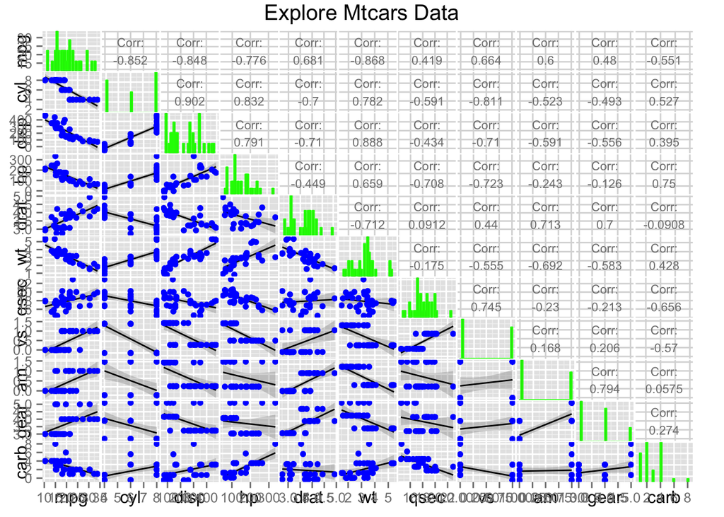

```r
pairs_plot <- ggpairs(data = mtcars
                      , columns = 1:ncol(mtcars)
                      , title = "Explore Mtcars Data"
                      , diag = list(continuous = "bar", params = c(color="green"))
                      , upper = list(params=list(size = 3), axisLabels = 'show')
                      , lower = list(continuous = "smooth", params = c(color="blue"))
)
pairs_plot
```

##### Chart #2

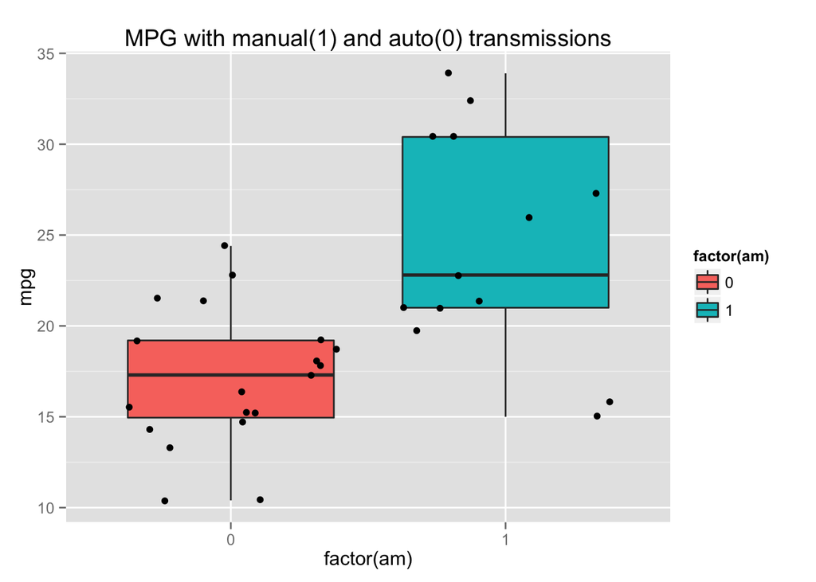

```r
mpg_boxplot <- ggplot(mtcars
                      , aes(factor(am)
                      , mpg)) +
    geom_boxplot(aes(fill = factor(am))) +
    geom_jitter() +
    ggtitle("MPG with manual(1) and auto(0) transmissions")
mpg_boxplot
```

##### Chart #3

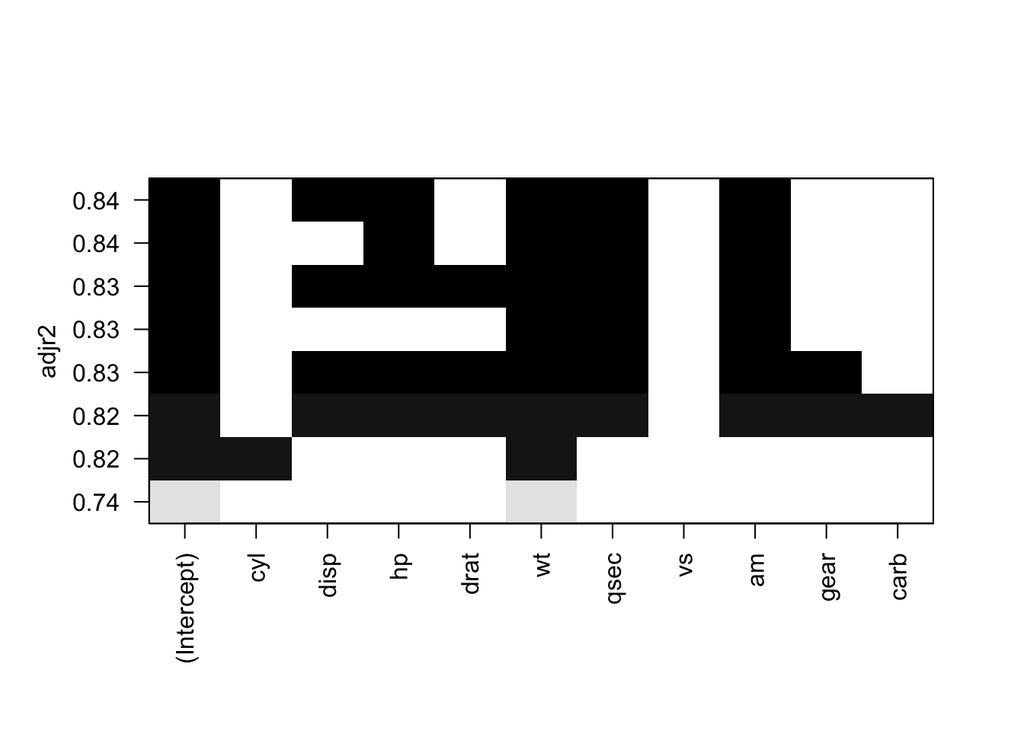

```r
model_select <- regsubsets(mpg ~ ., data = mtcars)
model_select_plot <- plot(model_select, scale = "adjr2")
```

##### Chart #4

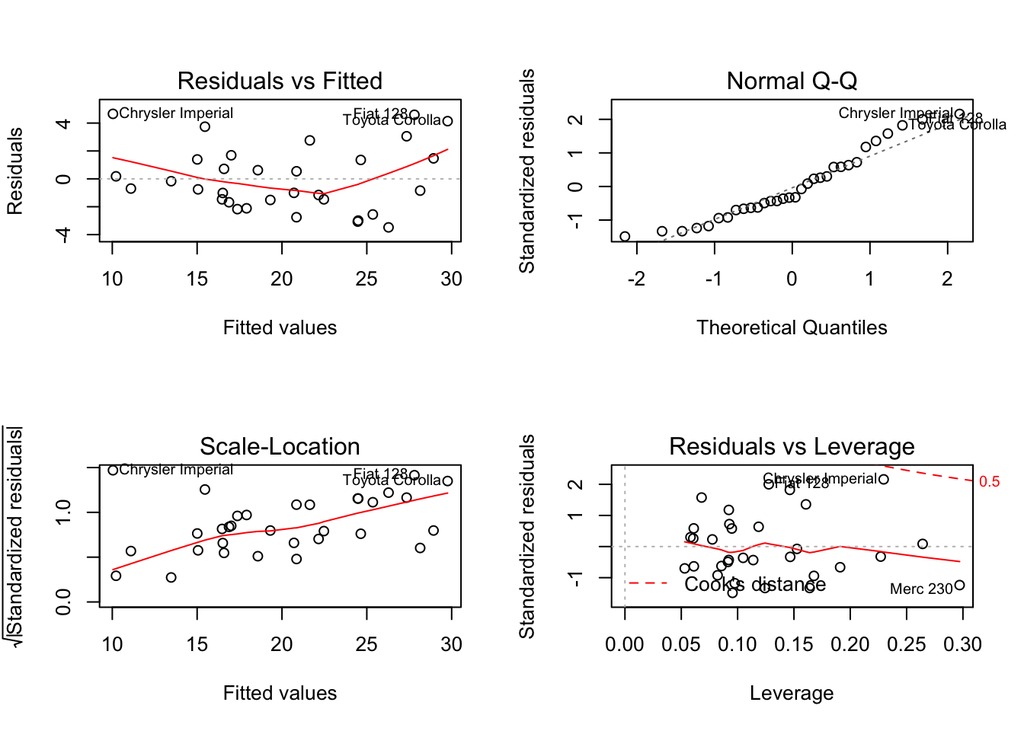

```r
par(mfrow = c(2, 2))
plot(best_model)
```